# ExtraaLearn Project

# **Bivariate Analysis:**

```python
# Creating a function to make and visualize a stacked barplot
def stacked_barplot(data, predictor, target, figsize=(13,10)):
  (pd.crosstab(data[predictor], data[target], normalize='index')*100).plot(kind='bar', stacked=True, figsize=figsize)
  plt.legend(loc="upper right")
  plt.ylabel(target)
  plt.show()
```

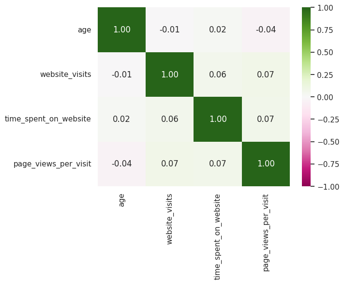

```python
# Creating a heatmap
column_list = data.select_dtypes(include=np.number).columns.tolist()

sns.heatmap(data[column_list].corr(), annot=True, vmin=-1, vmax=1, fmt=".2f", cmap="PiYG")
plt.show()
```

**Observations:**

- We cannot make any kind of observations from the heat map as all the values are not correlated to each other at all.

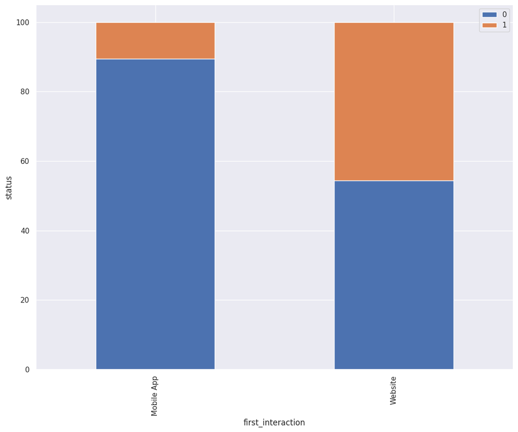

```python
stacked_barplot(data, 'first_interaction', 'status')
```

**Observations:**

- From this, we understand that most of leads who were converted to paid leads had their first interaction through the website.
- While the mobile app was not able to convert the leads successfully into paid leads.

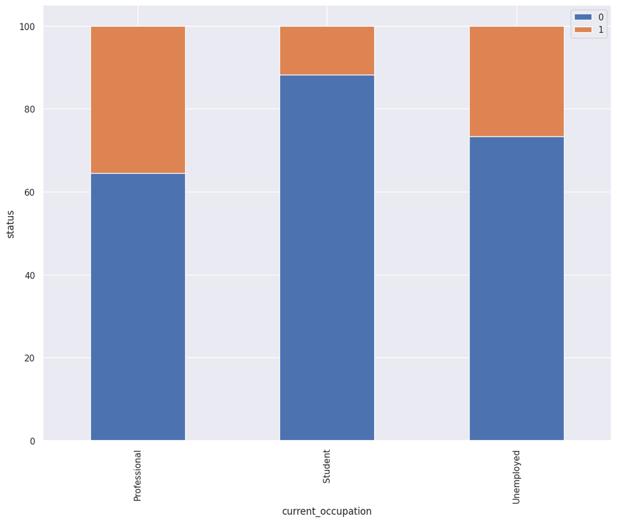

```python
stacked_barplot(data, 'current_occupation', 'status')
```

**Observations:**

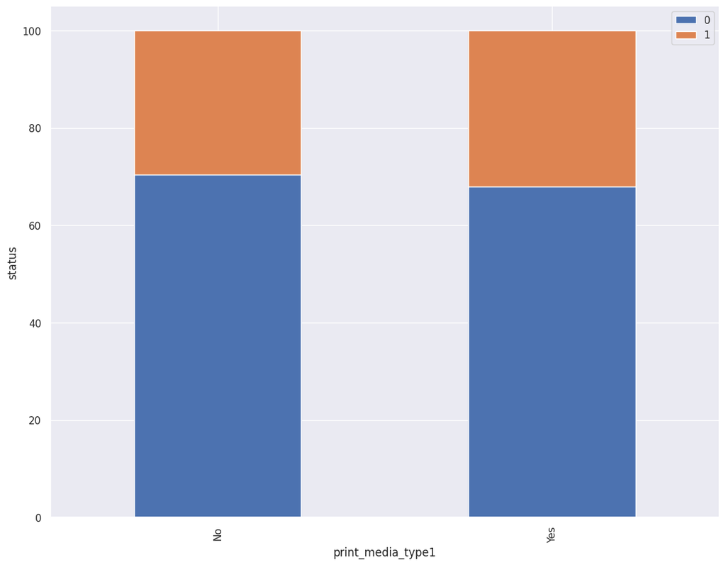

```python
stacked_barplot(data, 'print_media_type1','status')
```

**Observations:**

- Here, the leads were got the reference through the newspaper have been converted to paid leads more successfully compared to those who didn't through the newspaper.

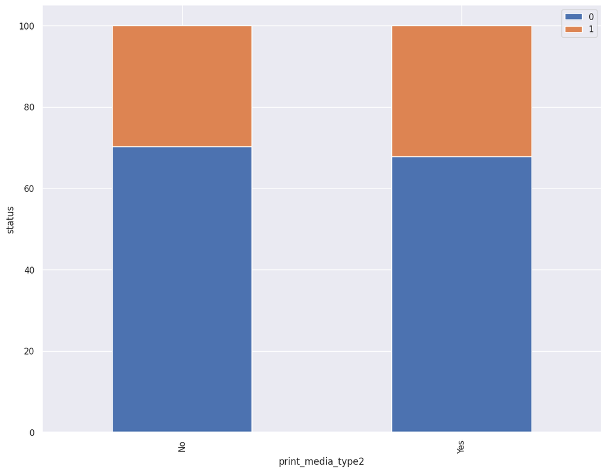

```python
stacked_barplot(data, 'print_media_type2', 'status')
```

**Observations:**

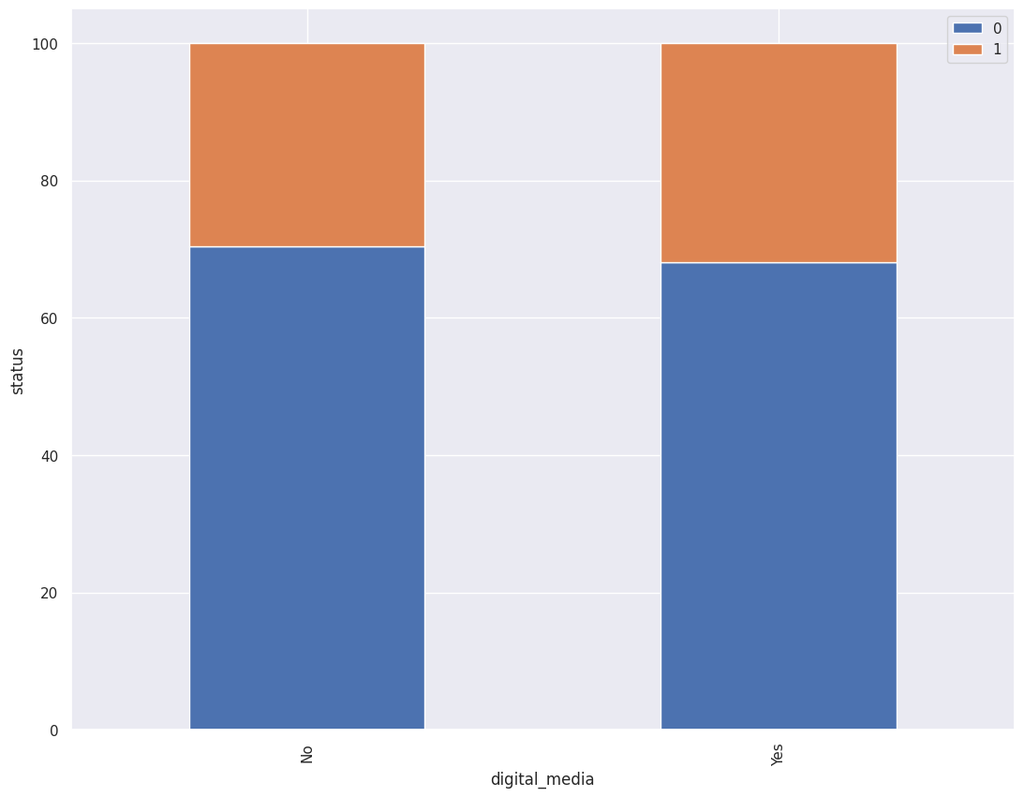

```python
stacked_barplot(data, 'digital_media', 'status')
```

**Observations:**

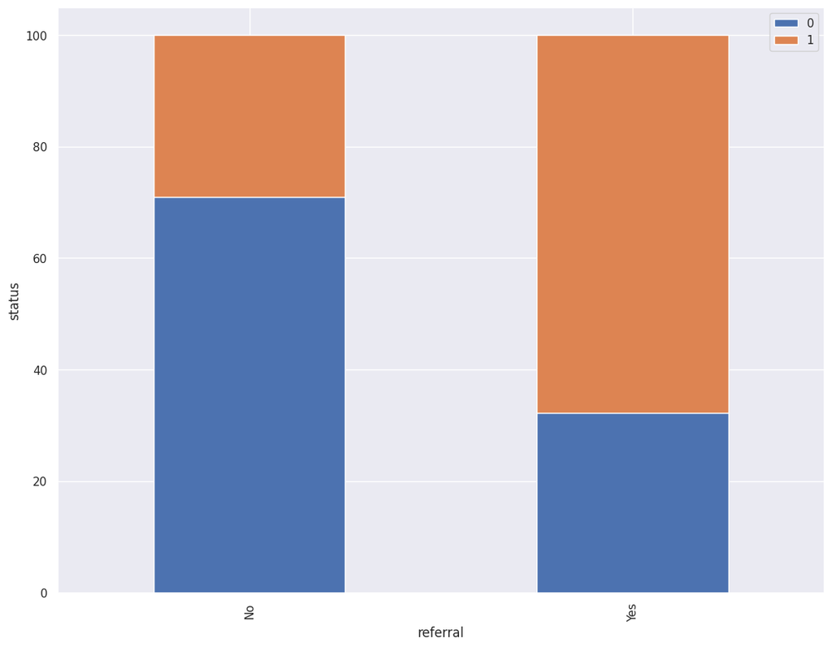

```python
stacked_barplot(data, 'referral', 'status');
```

**Observations:**

- The leads who their reference through a referral were successfully converted into paid leads.
- This shows that the people who referred the project to them were convinced to become paid leads.

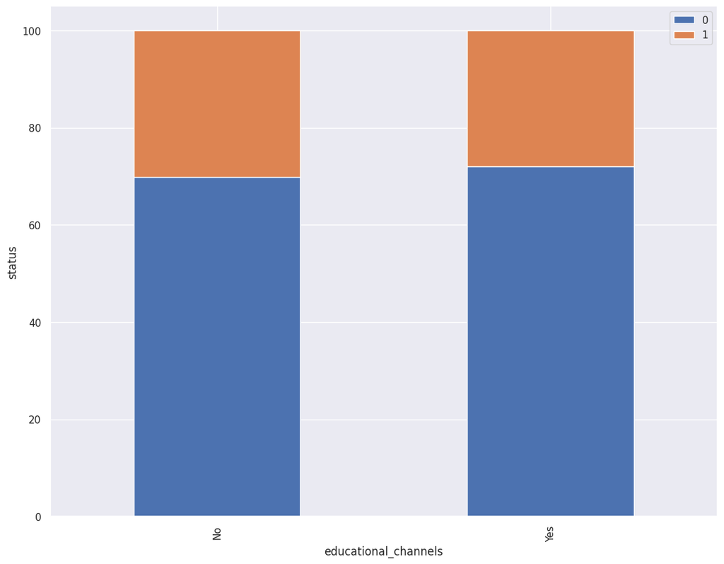

```python
stacked_barplot(data, 'educational_channels', 'status');
```

**Observations:**

- The educational channels were not successful enough to convert the leads into paid leads.
- Those who were introduced to ExtraaLearn through other mediums were more effectively able to convert the leads into paid leads compared to educational channels.